# H2O-3 Target Encoding Example

Also check out the original documentation http://docs.h2o.ai/h2o/latest-stable/h2o-docs/data-munging/target-encoding.html

## H2O Cluster

```r
library(h2o)
h2o.no_progress()
h2o.init()
```

```
 Connection successful!

R is connected to the H2O cluster:
    H2O cluster uptime:         18 seconds 754 milliseconds
    H2O cluster timezone:       Asia/Jerusalem
    H2O data parsing timezone:  UTC
    H2O cluster version:        3.22.1.4
    H2O cluster version age:    9 days
    H2O cluster name:           H2O_started_from_R_jofaichow_lvv153
    H2O cluster total nodes:    1
    H2O cluster total memory:   3.24 GB
    H2O cluster total cores:    8
    H2O cluster allowed cores:  8
    H2O cluster healthy:        TRUE
    H2O Connection ip:          localhost
    H2O Connection port:        54321
    H2O Connection proxy:       NA
    H2O Internal Security:      FALSE
    H2O API Extensions:         Amazon S3, XGBoost, Algos, AutoML, Core V3, Core V4
    R Version:                  R version 3.5.0 (2018-04-23)
```

## Data

```r
# Source: https://raw.githubusercontent.com/h2oai/app-consumer-loan/master/data/loan.csv
d_loan <- h2o.importFile("loan.csv")
d_loan$bad_loan <- as.factor(d_loan$bad_loan)
```

## Baseline Model

Randomly split the data into 75% training and 25% test We will use both cross-validation and test to evaluate how well the model performs.

```r
# Split Frame into training and test
splits <- h2o.splitFrame(d_loan, seed = 1234,
                         destination_frames=c("d_train", "d_test"),
                         ratios = 0.75)
d_train <- splits[[1]]
d_test <- splits[[2]]

# Assign 5-Fold
d_train$fold <- h2o.kfold_column(d_train, 5, seed = 1234)
```

```r
head(d_train)
```

|  | loan_amnt | term | int_rate | emp_length | home_ownership | annual_inc | purpose | addr_state | dti | delinq_2yrs | revol_util | total_acc | bad_loan | longest_credit_length | verification_status | fold |
| --- | --- | --- | --- | --- | --- | --- | --- | --- | --- | --- | --- | --- | --- | --- | --- | --- |
| 1 | 5000 | 36 months | 10.65 | 10 | RENT | 24000 | credit_card | AZ | 27.65 | 0 | 83.7 | 9 | 0 | 26 | verified | 2 |
| 2 | 2500 | 60 months | 15.27 | 0 | RENT | 30000 | car | GA | 1.00 | 0 | 9.4 | 4 | 1 | 12 | verified | 0 |
| 3 | 2400 | 36 months | 15.96 | 10 | RENT | 12252 | small_business | IL | 8.72 | 0 | 98.5 | 10 | 0 | 10 | not verified | 0 |
| 4 | 5000 | 36 months | 7.90 | 3 | RENT | 36000 | wedding | AZ | 11.20 | 0 | 28.3 | 12 | 0 | 7 | verified | 1 |
| 5 | 3000 | 36 months | 18.64 | 9 | RENT | 48000 | car | CA | 5.35 | 0 | 87.5 | 4 | 0 | 4 | verified | 3 |
| 6 | 5600 | 60 months | 21.28 | 4 | OWN | 40000 | small_business | CA | 5.55 | 0 | 32.6 | 13 | 1 | 7 | verified | 3 |

```r
head(d_test)
```

|  | loan_amnt | term | int_rate | emp_length | home_ownership | annual_inc | purpose | addr_state | dti | delinq_2yrs | revol_util | total_acc | bad_loan | longest_credit_length | verification_status |
| --- | --- | --- | --- | --- | --- | --- | --- | --- | --- | --- | --- | --- | --- | --- | --- |
| 1 | 10000 | 36 months | 13.49 | 10 | RENT | 49200.00 | other | CA | 20.00 | 0 | 21.0 | 37 | 0 | 15 | verified |
| 2 | 12000 | 36 months | 12.69 | 10 | OWN | 75000.00 | debt_consolidation | CA | 10.78 | 0 | 67.1 | 34 | 0 | 22 | verified |
| 3 | 10000 | 36 months | 15.27 | 4 | RENT | 42000.00 | home_improvement | CA | 18.60 | 0 | 70.2 | 28 | 0 | 13 | not verified |
| 4 | 9200 | 36 months | 6.03 | 6 | RENT | 77385.19 | debt_consolidation | CA | 9.86 | 0 | 23.1 | 28 | 0 | 10 | not verified |
| 5 | 21000 | 36 months | 12.42 | 10 | RENT | 105000.00 | debt_consolidation | FL | 13.22 | 0 | 90.3 | 38 | 1 | 28 | verified |
| 6 | 10000 | 36 months | 11.71 | 10 | OWN | 50000.00 | credit_card | TX | 11.18 | 0 | 82.4 | 21 | 0 | 26 | verified |

Now train the baseline model. We will train a GBM model with 5-fold CV & early stopping.

```r
response <- "bad_loan"
predictors <- c("loan_amnt", "int_rate", "emp_length", "annual_inc", "dti",
                "delinq_2yrs", "revol_util", "total_acc", "longest_credit_length",
                "verification_status", "term", "purpose", "home_ownership",
                "addr_state")

gbm_baseline <- h2o.gbm(x = predictors,
                        y = response,
                        training_frame = d_train,
                        score_tree_interval = 10,
                        ntrees = 500,
                        sample_rate = 0.8,
                        col_sample_rate = 0.8,
                        fold_column = "fold",
                        seed = 1234,
                        stopping_rounds = 5,
                        stopping_metric = "AUC",
                        model_id = "gbm_baseline")
```

GBM Baseline Model Evaluation (AUC, Higher = Better):

**Training**: `0.749742`

**5-Fold CV**: `0.7045098`

**Testing**: `0.7069701`

Our training data has much higher AUC than our validation data.

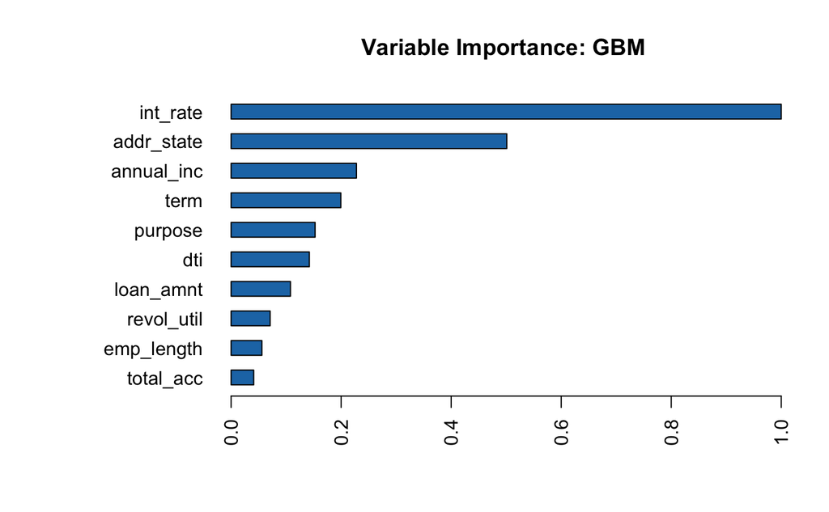

```r
# Variable Importance
h2o.varimp_plot(gbm_baseline)
```

## Baseline Model without `addr_state`

See if the AUC improves on the test data if we remove the addr_state predictor. This can indicate that the model is memorizing the training data.

```r
predictors <- setdiff(predictors, "addr_state")

gbm_no_addr <- h2o.gbm(x = predictors,
                       y = response,
                       training_frame = d_train,
                       score_tree_interval = 10,
                       ntrees = 500,
                       sample_rate = 0.8,
                       col_sample_rate = 0.8,
                       fold_column = "fold",
                       seed = 1234,
                       stopping_rounds = 5,
                       stopping_metric = "AUC",
                       model_id = "gbm_no_addr")
```

## Comparison

Let’s compare the baseline models with and without `addr_state`

**Evaluation (AUC, Higher = Better)**:

**Training** (with addr_state): `0.749742` vs. (without addr_state): `0.7330057`

**5-Fold CV** (with addr_state): `0.7045098` vs. (without addr_state): `0.7061583`

**Testing** (with addr_state): `0.7069701` vs. (without addr_state): `0.7076197`

We see a slight improvement in our test AUC if we do not include the `addr_state` predictor. This is a good indication that the GBM model may be overfitting with this column.

## Target Encoding in H2O-3

Start by creating the target encoding map. This has the number of bad loans per state (numerator) and the number of rows per state (denominator). We can later use this information to create the target encoding per state.

```r
te_map <- h2o.target_encode_create(d_train,
                                   x = list("addr_state"),
                                   y = response,
                                   fold_column = "fold")
head(te_map$addr_state)
```

|  | addr_state | fold | numerator | denominator |
| --- | --- | --- | --- | --- |
| 1 | AK | 0 | 7 | 52 |
| 2 | AK | 1 | 8 | 55 |
| 3 | AK | 2 | 7 | 56 |
| 4 | AK | 3 | 13 | 68 |
| 5 | AK | 4 | 8 | 70 |
| 6 | AL | 0 | 57 | 297 |

Apply the target encoding to our training data.

```r
d_train_te <- h2o.target_encode_apply(d_train,
                                      x = list("addr_state"),
                                      y = response,
                                      target_encode_map = te_map,
                                      holdout_type = "KFold",
                                      fold_column = "fold",
                                      blended_avg = TRUE,
                                      noise_level = 0,
                                      seed = 1234)

head(d_train_te[c("addr_state", "fold", "TargetEncode_addr_state")])
```

|  | addr_state | fold | TargetEncode_addr_state |
| --- | --- | --- | --- |
| 1 | AK | 0 | 0.1445783 |
| 2 | AK | 0 | 0.1445783 |
| 3 | AK | 0 | 0.1445783 |
| 4 | AK | 0 | 0.1445783 |
| 5 | AK | 0 | 0.1445783 |
| 6 | AK | 0 | 0.1445783 |

For testing data, we do not need to apply any of the overfitting prevention techniques since our target encoding map was created on the training data, not the testing data.

```r
d_test_te <- h2o.target_encode_apply(d_test,
                                     x = list("addr_state"),
                                     y = response,
                                     target_encode_map = te_map,
                                     holdout_type = "None",
                                     fold_column = "fold",
                                     blended_avg = FALSE,
                                     noise_level = 0)

head(d_test_te[c("addr_state", "TargetEncode_addr_state")])
```

|  | addr_state | TargetEncode_addr_state |
| --- | --- | --- |
| 1 | AK | 0.1428571 |
| 2 | AK | 0.1428571 |
| 3 | AK | 0.1428571 |
| 4 | AK | 0.1428571 |
| 5 | AK | 0.1428571 |
| 6 | AK | 0.1428571 |

```r
head(d_train_te)
```

|  | addr_state | fold | loan_amnt | term | int_rate | emp_length | home_ownership | annual_inc | purpose | dti | delinq_2yrs | revol_util | total_acc | bad_loan | longest_credit_length | verification_status | TargetEncode_addr_state |
| --- | --- | --- | --- | --- | --- | --- | --- | --- | --- | --- | --- | --- | --- | --- | --- | --- | --- |
| 1 | AK | 0 | 8400 | 36 months | 7.51 | 10 | RENT | 72000 | debt_consolidation | 20.75 | 1 | 16.0 | 23 | 1 | 15 | verified | 0.1445783 |
| 2 | AK | 0 | 23200 | 60 months | 20.89 | 10 | MORTGAGE | 125000 | debt_consolidation | 23.37 | 0 | 81.6 | 31 | 0 | 11 | verified | 0.1445783 |
| 3 | AK | 0 | 7500 | 36 months | 5.99 | 10 | RENT | 51000 | major_purchase | 14.73 | 0 | 0.7 | 23 | 0 | 12 | not verified | 0.1445783 |
| 4 | AK | 0 | 3500 | 36 months | 5.42 | NaN | OWN | 108000 | car | 0.81 | 0 | 3.3 | 25 | 0 | 41 | not verified | 0.1445783 |
| 5 | AK | 0 | 6300 | 60 months | 15.28 | 10 | MORTGAGE | 110004 | home_improvement | 21.52 | 0 | 80.1 | 25 | 0 | 11 | not verified | 0.1445783 |
| 6 | AK | 0 | 2000 | 60 months | 16.77 | 10 | RENT | 78000 | debt_consolidation | 24.40 | 2 | 91.6 | 51 | 0 | 16 | verified | 0.1445783 |

## Train Model with KFold Target Encoding

Train a new model, this time replacing the `addr_state` with the `TargetEncode_addr_state`.

```r
predictors <- c("loan_amnt", "int_rate", "emp_length", "annual_inc",
                "dti", "delinq_2yrs", "revol_util", "total_acc",
                "longest_credit_length", "verification_status",
                "term", "purpose", "home_ownership",
                "TargetEncode_addr_state")

gbm_te <- h2o.gbm(x = predictors,
                  y = response,
                  training_frame = d_train_te, # new data frame
                  score_tree_interval = 10,
                  ntrees = 500,
                  sample_rate = 0.8,
                  col_sample_rate = 0.8,
                  fold_column = "fold",
                  seed = 1234,
                  stopping_rounds = 5,
                  stopping_metric = "AUC",
                  model_id = "gbm_te")
```

## Comparison

Let’s compare all three models:

**Evaluation (AUC, Higher = Better)**:

**Training** (with addr_state): `0.749742` vs. (without addr_state): `0.7330057` vs. (with TE): `0.7309827`

**5-Fold CV** (with addr_state): `0.7045098` vs. (without addr_state): `0.7061583` vs. (with TE): `0.7072099`

**Test** (with addr_state): `0.7069701` vs. (without addr_state): `0.7076197` vs. (with TE) `0.708911`

We see a slight increase in the AUC on validation data. Also, the `addr_state` with target encoding has much smaller variable importance.

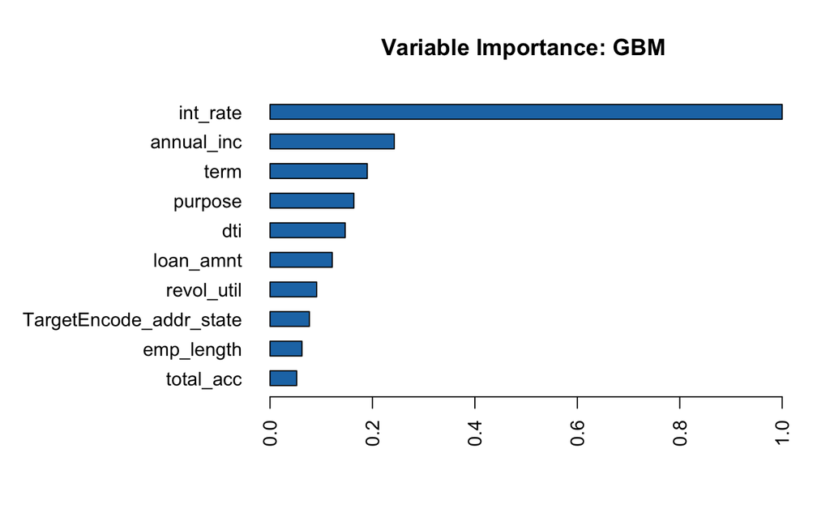

```r
# Variable Importance
h2o.varimp_plot(gbm_te)
```